# Escalonamento e Transformação de Dados

Prof. Cesar Henrique Comin

## Colunas possuem escalas diferentes

```python
diabetes = pd.read_csv("../dados/diabetic_data.csv", na_values="?")

columns = ["time_in_hospital", "num_lab_procedures", "num_medications"]
print(diabetes[columns].describe().loc[["mean", "std", "min", "max"]].round(1))
```

```
      time_in_hospital  num_lab_procedures  num_medications
mean               4.7                46.6             14.9
std                3.2                18.2              7.9
min                1.0                 1.0              1.0
max               14.0               114.0             62.0
```

## O problema: distâncias

- Muitas técnicas resumem pares de linhas a **um número**: a distância entre elas.

$$d(x, y) = \sqrt{\sum_{j} (x_j - y_j)^2}$$

- Cada coluna contribui com $(x_j - y_j)^2$.
- A coluna com a **maior amplitude numérica** domina a soma, independente da sua relevância.
- O termo **escalonamento** se refere a **colocar todas as colunas na mesma escala**.

## Métodos que precisam de escalonamento

- **Métodos baseados em distância:** k-NN, k-means, DBSCAN, PCA, SVM com kernel RBF.
- **Otimização por gradiente:** regressão logística, redes neurais.
- **Modelos regularizados (L1/L2):** a penalidade incide sobre o tamanho do coeficiente. Uma variável com escala maior é penalizada menos.

## Métodos que não precisam

- **Árvores de decisão, Random Forest, Gradient Boosting.**
- Uma árvore faz perguntas do tipo `coluna_j <= t?`, uma coluna de cada vez.
- Qualquer transformação **monotônica** (que preserva a ordem) apenas renomeia o limiar $t$. A árvore resultante é a mesma.

# Escalonamento

## `MinMaxScaler`

$$x' = \frac{x - x_{\min}}{x_{\max} - x_{\min}}$$

- Leva o **mínimo do treino** para 0 e o **máximo do treino** para 1.
- É uma transformação **afim**: a forma da distribuição é preservada exatamente.
- Parâmetros aprendidos: `data_min_` e `data_max_`.

## Exemplo do `MinMaxScaler`

```python
from sklearn.preprocessing import MinMaxScaler

train = pd.DataFrame({"nota": [5.0, 7.0, 9.0]})
test = pd.DataFrame({"nota": [4.0, 10.0]})

mm = MinMaxScaler().fit(train)
print("data_min_:", mm.data_min_, "| data_max_:", mm.data_max_)
print("teste [4, 10]:", mm.transform(test).ravel())
```

```
data_min_: [5.] | data_max_: [9.]
teste [4, 10]: [-0.25  1.25]
```

## `MinMaxScaler`: o intervalo não é garantido

- A nota 4 virou **-0.25** e a nota 10 virou **1.25**.
- A garantia $[0,1]$ vale **só para o treino**. Na inferência, valores novos saem do intervalo.
- `MinMaxScaler(clip=True)` força o resultado para dentro de $[0,1]$.

## `StandardScaler`

$$z = \frac{x - \mu}{\sigma}$$

- Resultado com média 0 e desvio-padrão 1. Parâmetros: `mean_` e `scale_`.
- É um padrão muito comum: funciona bem com quase tudo e não depende de valores extremos isolados tanto quanto o `MinMaxScaler`.
- Não limita o intervalo, é possível ter valores muito grandes ou muito pequenos.

## `RobustScaler`

$$x' = \frac{x - \text{mediana}}{Q_3 - Q_1}$$

- Troca a média pela **mediana** e o desvio-padrão pelo **intervalo interquartil** (IQR).
- Nenhuma das estatísticas é afetada por valores extremos: uma linha com valor extremo não move a mediana nem os quartis.
- `quantile_range=(25.0, 75.0)` por padrão. Também é comum utilizar `(5.0, 95.0)`.

## O efeito de outliers

```python
from sklearn.preprocessing import StandardScaler, RobustScaler

rng = np.random.default_rng(0)

values = np.concatenate(
  [rng.normal(50, 10, 990),     # 990 leituras normais
  rng.normal(5000, 100, 10)])   # 10 leituras anormais
X = pd.DataFrame({"leitura": values})

for name, scaler in [("MinMax", MinMaxScaler()),
                     ("Standard", StandardScaler()),
                     ("Robust", RobustScaler())]:
    output = scaler.fit_transform(X).ravel()
    p1, p99 = np.percentile(output[:990], [1, 99])       # onde ficaram os dados normais
    print(f"{name:>9}: 98% dos dados normais ocupam a faixa [{p1:7.3f}, {p99:6.3f}]")
```

```
   MinMax: 98% dos dados normais ocupam a faixa [  0.003,  0.012]
 Standard: 98% dos dados normais ocupam a faixa [ -0.149, -0.054]
   Robust: 98% dos dados normais ocupam a faixa [ -1.790,  1.724]
```

## O efeito de outliers

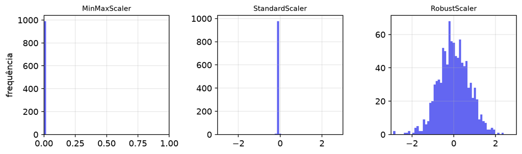

- Cada gráfico mostra os 990 dados *não outliers* dentro da faixa que se espera do escalador.

## `Normalizer`

- Cuidado: o `Normalizer` do sklearn não escalona colunas. Ele divide cada linha pela sua norma. É outra operação, usada em *embeddings* de dados (imagens, textos, etc).

## `set_output`: mantendo o DataFrame

- Por padrão os transformadores devolvem um `array` do numpy e os nomes das colunas se perdem.
- `set_output(transform="pandas")` mantém o DataFrame como saída do transformador do sklearn.

```python
records = pd.DataFrame({
    "idade": [25, 60, 26, 41, 33, 52],
    "renda": [3000.0, 3100.0, 8000.0, 5200.0, 4100.0, 12000.0],
}, index=["Ana", "Bruno", "Carla", "Diego", "Elisa", "Fabio"])

scaler = StandardScaler().set_output(transform="pandas")
print(scaler.fit_transform(records).round(2))
```

```
       idade  renda
Ana    -1.12  -0.91
Bruno   1.58  -0.87
Carla  -1.04   0.66
Diego   0.12  -0.22
Elisa  -0.50  -0.56
Fabio   0.96   1.90
```

## Quadro-resumo

| Escalador | Escala | Intervalo fixo? | Robusto? |  |  |
| --- | --- | --- | --- | --- | --- |
| `MinMaxScaler` | amplitude | $[0,1]$ no treino | não |  |  |
| `StandardScaler` | desvio | não | não |  |  |
| `RobustScaler` | IQR | não | sim |  |  |

- Na dúvida: `StandardScaler`. Com outliers ou cauda longa: `RobustScaler`.
- `MinMaxScaler` quando a análise exige um intervalo limitado.

# Assimetria e caudas longas

## O que é assimetria

- Uma distribuição é **assimétrica à direita** quando poucos valores muito grandes puxam a *cauda* da distribuição.
- Indicativo: a **média é maior que a mediana**.

```python
x = diabetes["num_medications"]
print(f"média: {x.mean():.1f} | mediana: {x.median():.1f} | skew: {x.skew():.2f}")
```

```
média: 14.9 | mediana: 14.0 | skew: 1.33
```

- `Series.skew()` mede a simetria em um número:
  - zero: distribuição simétrica
  - positivo: assimétrica à direita
  - negativo: assimétrica à esquerda

## O gráfico Q-Q

- O gráfico **quantil-quantil** mostra o quanto uma distribuição se afasta de uma referência. Em geral, a referência é a distribuição normal.
- Cada ponto é um quantil dos dados contra o quantil correspondente da normal. Se a distribuição fosse normal, os pontos cairiam sobre uma reta.

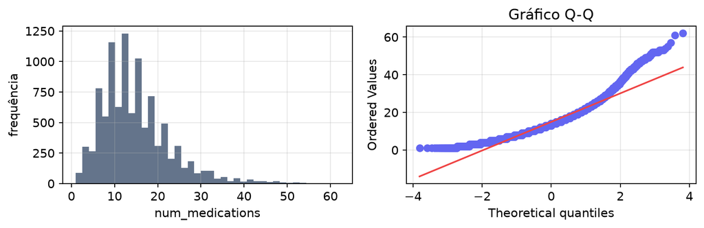

## O gráfico Q-Q

- O gráfico pode ser gerado com o código:

```python
from scipy import stats

stats.probplot(x, dist="norm")
```

## Por que a assimetria é problemática

- Poucos valores grandes dominam a **variância** e, portanto, dominam a distância, o PCA e qualquer método de mínimos quadrados.
- Correlações lineares ficam distorcidas por alguns poucos pontos.
- Em muitos domínios, variáveis são **multiplicativas**, não aditivas: um aumento de salário tende a ser maior quanto maior o salário atual.

## Um exemplo: renda e satisfação

```python
rng = np.random.default_rng(1)

income = rng.lognormal(np.log(3000), 1.0, 400)                   # R$ por mês
satisfaction = 1.2*np.log(income) - 4 + rng.normal(0, 0.4, 400)  # depende do log da renda

survey = pd.DataFrame({"renda": income.round(0), "satisfacao": satisfaction.round(2)})
print(f"skew da renda: {survey['renda'].skew():.2f}")
```

```
skew da renda: 5.87
```

## Regressão linear na escala original

```python
from sklearn.linear_model import LinearRegression

X = survey[["renda"]]
y = survey["satisfacao"]

model = LinearRegression().fit(X, y)
print(f"R²: {model.score(X, y):.2f}")
```

```
R²: 0.48
```

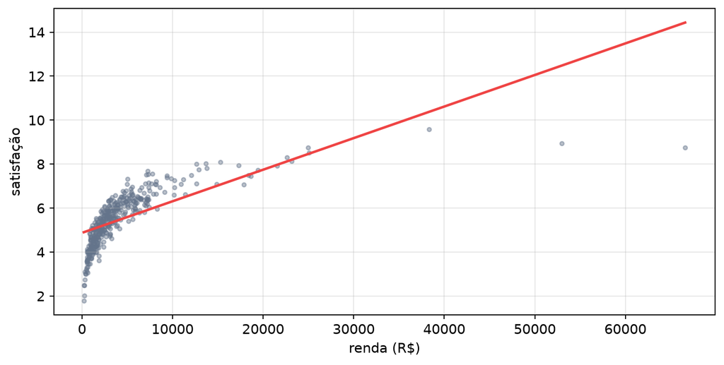

## Regressão linear na escala original

- A reta erra de forma **sistemática**: fica acima dos dados na renda baixa, abaixo na renda média.
- Ela também prevê satisfação **acima de 10** para as rendas altas.
- O $R^2$ de 0.48 é baixo apesar de existir uma relação forte e bem definida entre as duas variáveis.

## `log1p`: uma transformação para cauda longa

- $\log(1+x)$: comprime a cauda e preserva o zero. A função é **monotônica**: a ordem dos valores não muda.
- Em escala logarítmica, **diferenças viram razões**: a distância entre 10 e 20 é a mesma entre 100 e 200.
- É uma escolha natural para grandezas positivas que crescem de forma multiplicativa: preço, renda, contagem, população, tempo de resposta.

## `log1p` pode “inverter” a cauda

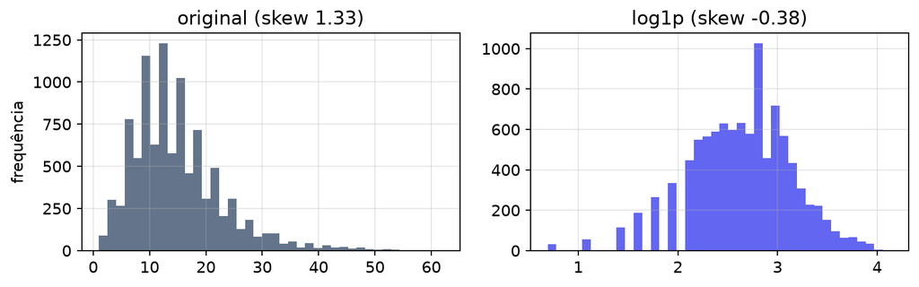

## `PowerTransformer`

- É possível aprender a transformação que deixa o resultado mais próximo de uma normal.
- Transformação **Box-Cox**:

$$x^{(\lambda)} = \begin{cases} \dfrac{x^{\lambda} - 1}{\lambda}, & \lambda \neq 0 \\[6pt] \ln x, & \lambda = 0\end{cases}$$

- $\lambda$ é estimado a partir dos dados.

## Box-Cox vs. Yeo-Johnson

- Box-Cox não aceita zero nem valores negativos.
- **Yeo-Johnson** estende o Box-Cox para incluir valores zero e negativos.

```python
from sklearn.preprocessing import PowerTransformer

X_med = diabetes["num_medications"].to_frame()
yj = PowerTransformer().fit(X_med)                       # yeo-johnson
bc = PowerTransformer(method="box-cox").fit(X_med)

for name, transformer in [("Yeo-Johnson", yj), ("Box-Cox", bc)]:
    skew = pd.Series(transformer.transform(X_med).ravel()).skew()
    print(f"skew {name}: {skew:.3f}")
```

```
skew Yeo-Johnson: 0.012
skew Box-Cox: 0.025
```

## Voltando à regressão linear

```python
X = survey[["renda"]]
y = survey["satisfacao"]

pt = PowerTransformer().fit(X)                   # yeo-johnson na renda
X_pt = pt.transform(X)

model_pt = LinearRegression().fit(X_pt, y)
print(f"lambda estimado: {pt.lambdas_[0]:.3f}")
print(f"R² antes: {model.score(X, y):.3f} | R² depois: {model_pt.score(X_pt, y):.3f}")
```

```
lambda estimado: -0.022
R² antes: 0.481 | R² depois: 0.877
```

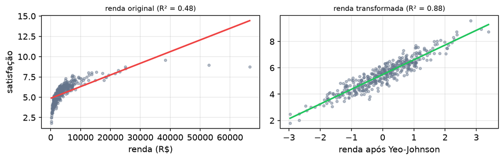

## Voltando à regressão linear

- O $\lambda$ estimado ficou em $-0.02$, ou seja, o método redescobriu a relação logarítmica.
- A mesma regressão linear passou de $R^2 = 0.48$ para $R^2 = 0.88$.

## `QuantileTransformer`

- Cada valor é substituído pela sua **posição relativa** (o quantil), e essa posição é remapeada para a distribuição-alvo.
- `output_distribution="uniform"` (padrão) ou `"normal"`.
- É uma transformação de **posto**: só a ordem dos valores importa.

```python
from sklearn.preprocessing import QuantileTransformer

qt = QuantileTransformer(output_distribution="normal", random_state=0).fit(X_med)
print(f"skew depois: {pd.Series(qt.transform(X_med).ravel()).skew():.3f}")
```

```
skew depois: -0.300
```

## `QuantileTransformer` — comparação

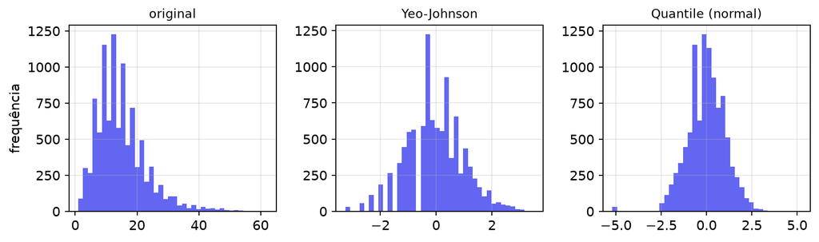

## Problemas do `QuantileTransformer`

- **Remove as distâncias reais**: o intervalo entre o 99º e o 100º percentil passa a valer o mesmo que entre o 50º e o 51º.
- **Satura os extremos:** Qualquer valor acima do máximo do treino recebe o mesmo valor de saída.

## Como escolher

- Comece pelo **domínio**: se a grandeza é positiva e multiplicativa (preço, renda, contagem, tempo), `log1p` é interessante.
- Se o log corrigir de menos ou de mais, o `PowerTransformer` pode ser usado.
- Se houver muitas colunas para tratar e nenhuma exigência de interpretação, o `QuantileTransformer` corrige a assimetria.